# Soc723 - MD Chapter 6

Turgut Keskintürk

2023-01-16

Hello there! Let’s start with our exercises for Chapter 6.

```r
d <- read.csv(
  "https://raw.githubusercontent.com/vaiseys/223_course/main/Data/gender_employment.csv"
) |> clean_names()
```

# Question 1

Let’s fit our model:

```r
# some data tweaks
d <- d |>
  mutate(
    major_category = as.factor(major_category),
    major_category = relevel(major_category, ref = "Management, Business, and Financial")
  ) |>
  mutate(year = year - 2013) # gonna center the year at 0 to avoid bad intercept

# fit the data, and name it something other than nico's ridiculously long name
fit <- lm(wage_percent_of_male ~ year + major_category, data = d)

# show me
fit |> tidy() |>
  select(-p.value) |>
  mutate(term = str_remove(term, pattern = "major_category"),
         term = ifelse(term == "year", "Year", term)) |> # prettify
  kable(digits = 2, align = "lcccc")
```

| term | estimate | std.error | statistic |
| --- | --- | --- | --- |
| (Intercept) | 80.20 | 0.70 | 113.90 |
| Year | 0.19 | 0.23 | 0.84 |
| Computer, Engineering, and Science | 6.32 | 0.95 | 6.68 |
| Education, Legal, Community Service, Arts, and Media | 5.76 | 0.99 | 5.84 |
| Healthcare Practitioners and Technical | 5.52 | 1.10 | 5.00 |
| Natural Resources, Construction, and Maintenance | 4.91 | 1.24 | 3.95 |
| Production, Transportation, and Material Moving | -1.31 | 0.96 | -1.37 |
| Sales and Office | 3.33 | 0.86 | 3.88 |
| Service | 6.08 | 0.88 | 6.87 |

OK, it seems that there is not much trend overall in terms of year, even though there is a slight (very slight!) positive take. It is insane that the Management degrees produce such an asshole wage distribution (though not insane perhaps, but predictable).

# Question 2

Let’s see if the parallel trends assumption is warranted:

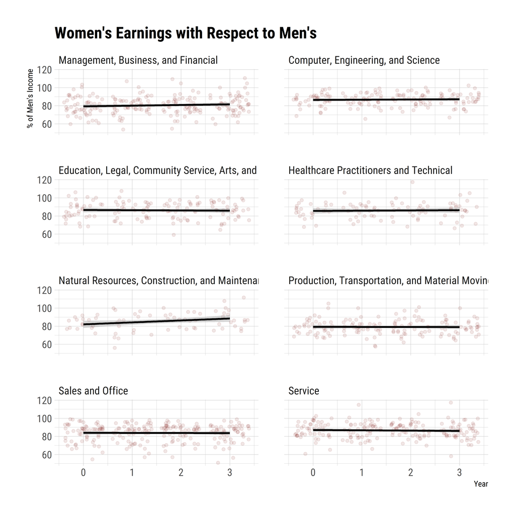

```r
d |>
  ggplot(aes(x = year, y = wage_percent_of_male)) +
  geom_jitter(alpha = 0.1, col = "#720500") +
  geom_smooth(method = "lm", col = "black") +
  labs(title = "Women's Earnings with Respect to Men's",
       y = "% of Men's Income",
       x = "Year") +
  facet_wrap(~major_category, nrow = 4)
```

Seems like it, with the exception of `Natural Resources, Constuction, and Maintenance`, which shows an uptick for this category.

# Question 3

Let’s do the interaction and inspect the results.

```r
# fit
int <- lm(wage_percent_of_male ~ year * major_category, data = d)

# show me
int |> tidy() |>
  select(-p.value) |>
  mutate(
    term = str_replace(term, pattern = "year:major_category", "Interaction: Year x "),
    term = str_remove(term, pattern = "major_category"),
    term = ifelse(term == "year", "Year", term)) |> # prettify
  kable(digits = 2, align = "lcccc")
```

| term | estimate | std.error | statistic |
| --- | --- | --- | --- |
| (Intercept) | 79.40 | 1.03 | 77.02 |
| Year | 0.72 | 0.55 | 1.31 |
| Computer, Engineering, and Science | 7.07 | 1.58 | 4.48 |
| Education, Legal, Community Service, Arts, and Media | 7.20 | 1.65 | 4.36 |
| Healthcare Practitioners and Technical | 6.19 | 1.85 | 3.35 |
| Natural Resources, Construction, and Maintenance | 2.64 | 2.12 | 1.24 |
| Production, Transportation, and Material Moving | -0.14 | 1.61 | -0.08 |
| Sales and Office | 4.52 | 1.43 | 3.16 |
| Service | 7.68 | 1.49 | 5.15 |
| Interaction: Year x Computer, Engineering, and Science | -0.49 | 0.85 | -0.59 |
| Interaction: Year x Education, Legal, Community Service, Arts, and Media | -0.96 | 0.88 | -1.09 |
| Interaction: Year x Healthcare Practitioners and Technical | -0.45 | 0.99 | -0.45 |
| Interaction: Year x Natural Resources, Construction, and Maintenance | 1.44 | 1.11 | 1.30 |
| Interaction: Year x Production, Transportation, and Material Moving | -0.78 | 0.86 | -0.91 |
| Interaction: Year x Sales and Office | -0.80 | 0.76 | -1.04 |
| Interaction: Year x Service | -1.06 | 0.79 | -1.34 |

# Question 4

We do not want to overfit our model to the data, and well, *less is better.*

# Question 5

We are still interested in how `wage_percent_of_male` changed across these years. Let’s fit some models and describe:

```r
# fits
fit1 <- lm(wage_percent_of_male ~ year, data = d)

# show me
fit1 |> tidy() |>
  select(-p.value) |> # this is not necessary I know, but it's fun
  mutate(term = ifelse(term == "year", "Year", term)) |> # same
  kable(digits = 2, align = "lcccc")
```

| term | estimate | std.error | statistic |
| --- | --- | --- | --- |
| (Intercept) | 83.73 | 0.45 | 187.92 |
| Year | 0.20 | 0.24 | 0.85 |

As we talked above, there is a slight uptick, but it’s not much clear what’s going on with this model. We are going to add `percent_female` to our model toolkit. Let’s see the correlation among these variables.

```r
d |>
  select(year, wage_percent_of_male, percent_female) %>%
  cor(use = "complete.obs") |>
  kable(digits = 2, align = "ccc")
```

|  | year | wage_percent_of_male | percent_female |
| --- | --- | --- | --- |
| year | 1.00 | 0.02 | 0.00 |
| wage_percent_of_male | 0.02 | 1.00 | 0.11 |
| percent_female | 0.00 | 0.11 | 1.00 |

OK, the correlations are pretty low, though `percent_female` might pick up some of the variation here. Let’s build:

```r
# fits
fit2 <- lm(wage_percent_of_male ~ year + percent_female, data = d)

# show me
fit2 |> tidy() |>
  select(-p.value) |> # this is not necessary I know, but it's fun
  mutate(term = ifelse(term == "year", "Year", term),
         term = ifelse(term == "percent_female", "% Female", term)) |> # same
  kable(digits = 2, align = "lcccc")
```

| term | estimate | std.error | statistic |
| --- | --- | --- | --- |
| (Intercept) | 81.79 | 0.66 | 123.51 |
| Year | 0.20 | 0.24 | 0.83 |
| % Female | 0.04 | 0.01 | 3.94 |

No, practically no change. This model basically means that conditioning on percent_female does not change `year` effects.

# Question 6

R-Squared is, as the term implies, the square of R (lol), which is the explained variance in the dependent variable that can be attributed to the set of independent variables used in our model. This is a sloppy definition, but it should work.

Let’s compare the model $R^2$:

```r
glance(fit1)$r.squared
```

```
## [1] 0.0005778711
```

```r
glance(fit2)$r.squared
```

```
## [1] 0.01297574
```

Not surprisingly, the $R^2$ of the second model is higher than the first model. I do not want to conclude anything from this, to be honest. Just that `percent_women` has some sort of relationship to the outcome, and it is nice to pick that up.

Thank you!